# MODULE 6 CLUSTERING PROJECT

## AllLife Bank Customer Segmentation - Problem Statement

### Description

#### Context

AllLife Bank wants to focus on its credit card customer base in the next financial year. They have been advised by their marketing research team, that the penetration in the market can be improved. Based on this input, the Marketing team proposes to run personalized campaigns to target new customers as well as upsell to existing customers. Another insight from the market research was that the customers perceive the support services of the bank poorly. Based on this, the Operations team wants to upgrade the service delivery model, to ensure that customer queries are resolved faster. Head of Marketing and Head of Delivery both decide to reach out to the Data Science team for help

#### Objective

To identify different segments in the existing customer, based on their spending patterns as well as past interaction with the bank, using clustering algorithms, and provide recommendations to the bank on how to better market to and service these customers.

#### Data Description

The data provided is of various customers of a bank and their financial attributes like credit limit, the total number of credit cards the customer has, and different channels through which customers have contacted the bank for any queries (including visiting the bank, online and through a call center).

#### Data Dictionary

- Sl_No: Primary key of the records
- Customer Key: Customer identification number
- Average Credit Limit: Average credit limit of each customer for all credit cards
- Total credit cards: Total number of credit cards possessed by the customer
- Total visits bank: Total number of visits that customer made (yearly) personally to the bank
- Total visits online: Total number of visits or online logins made by the customer (yearly)
- Total calls made: Total number of calls made by the customer to the bank or its customer service department (yearly)

### Importing Relevant Libraries

```python
# this will help in making the Python code more structured automatically
%load_ext nb_black

# Libraries to help with reading and manipulating data
import numpy as np
import pandas as pd

# Libraries to help with data visualization
import matplotlib.pyplot as plt
import seaborn as sns

# Removes the limit for the number of displayed columns
pd.set_option("display.max_columns", None)
# Sets the limit for the number of displayed rows
pd.set_option("display.max_rows", 200)

# to scale the data using z-score
from scipy.stats import zscore

# to compute distances
from scipy.spatial.distance import cdist
from scipy.spatial.distance import pdist  # Pairwise distribution between data points

# to perform k-means clustering and compute silhouette scores
from sklearn.cluster import KMeans
from sklearn.metrics import silhouette_score

# to visualize the elbow curve and silhouette scores
from yellowbrick.cluster import KElbowVisualizer, SilhouetteVisualizer

# to perform hierarchical clustering, compute cophenetic correlation, and create dendrograms
from sklearn.cluster import AgglomerativeClustering
from scipy.cluster.hierarchy import dendrogram, linkage, cophenet
```

```python
# loading the data set
data = pd.read_excel("Credit+Card+Customer+Data.xlsx")
data.head(20)
```

|  | Sl_No | Customer Key | Avg_Credit_Limit | Total_Credit_Cards | Total_visits_bank | Total_visits_online | Total_calls_made |
| --- | --- | --- | --- | --- | --- | --- | --- |
| 0 | 1 | 87073 | 100000 | 2 | 1 | 1 | 0 |
| 1 | 2 | 38414 | 50000 | 3 | 0 | 10 | 9 |
| 2 | 3 | 17341 | 50000 | 7 | 1 | 3 | 4 |
| 3 | 4 | 40496 | 30000 | 5 | 1 | 1 | 4 |
| 4 | 5 | 47437 | 100000 | 6 | 0 | 12 | 3 |
| 5 | 6 | 58634 | 20000 | 3 | 0 | 1 | 8 |
| 6 | 7 | 48370 | 100000 | 5 | 0 | 11 | 2 |
| 7 | 8 | 37376 | 15000 | 3 | 0 | 1 | 1 |
| 8 | 9 | 82490 | 5000 | 2 | 0 | 2 | 2 |
| 9 | 10 | 44770 | 3000 | 4 | 0 | 1 | 7 |
| 10 | 11 | 52741 | 10000 | 4 | 0 | 5 | 5 |
| 11 | 12 | 52326 | 13000 | 3 | 0 | 2 | 7 |
| 12 | 13 | 92503 | 11000 | 1 | 2 | 5 | 9 |
| 13 | 14 | 25084 | 9000 | 1 | 1 | 5 | 6 |
| 14 | 15 | 68517 | 6000 | 2 | 2 | 4 | 6 |
| 15 | 16 | 55196 | 8000 | 2 | 0 | 5 | 7 |
| 16 | 17 | 62617 | 15000 | 2 | 1 | 2 | 4 |
| 17 | 18 | 96463 | 8000 | 2 | 0 | 3 | 4 |
| 18 | 19 | 39137 | 11000 | 2 | 2 | 2 | 7 |
| 19 | 20 | 14309 | 19000 | 4 | 1 | 5 | 8 |

- The dataset looks consistent with the description provided in the Data Dictionary. However, the 'Sl_No' and 'Customer Key' columns do not contain any information relevant to the project objectives. These columns will be dropped shortly in the project.

```python
df = data.copy()  # To save a copy of the original data
```

```python
df.shape  # To check the number of rows and columns in the data set
```

```
(660, 7)
```

- The dataset has 660 rows and 7 columns

```python
df.duplicated().sum()  # To check for duplicated rows in the data set
```

```
0
```

- There is no duplicated row in the data set

```python
df.info()  # To print the concise summary of the dataset
```

```
<class 'pandas.core.frame.DataFrame'>
RangeIndex: 660 entries, 0 to 659
Data columns (total 7 columns):
 #   Column               Non-Null Count  Dtype
---  ------               --------------  -----
 0   Sl_No                660 non-null    int64
 1   Customer Key         660 non-null    int64
 2   Avg_Credit_Limit     660 non-null    int64
 3   Total_Credit_Cards   660 non-null    int64
 4   Total_visits_bank    660 non-null    int64
 5   Total_visits_online  660 non-null    int64
 6   Total_calls_made     660 non-null    int64
dtypes: int64(7)
memory usage: 36.2 KB
```

- It can be further seen that there are a total of 7 columns and 660 rows in the dataset.
- All columns' data types are of integer type.
- The number of non-null value in all columns is equal to number of total rows in the dataset.This means that the features do not contain missing observations. We can further confirm this using `isna()` method.

```python
df.isnull().sum()  # To further confirm if there are missing values in the dataset or not
```

```
Sl_No                  0
Customer Key           0
Avg_Credit_Limit       0
Total_Credit_Cards     0
Total_visits_bank      0
Total_visits_online    0
Total_calls_made       0
dtype: int64
```

- There is no missingness in the data set

```python
# let's drop Sl_No and Customer Key column
df.drop(["Sl_No", "Customer Key"], axis=1, inplace=True)
```

```python
df.describe().T  # To display the statistical summary of the features
```

|  | count | mean | std | min | 25% | 50% | 75% | max |
| --- | --- | --- | --- | --- | --- | --- | --- | --- |
| Avg_Credit_Limit | 660.0 | 34574.242424 | 37625.487804 | 3000.0 | 10000.0 | 18000.0 | 48000.0 | 200000.0 |
| Total_Credit_Cards | 660.0 | 4.706061 | 2.167835 | 1.0 | 3.0 | 5.0 | 6.0 | 10.0 |
| Total_visits_bank | 660.0 | 2.403030 | 1.631813 | 0.0 | 1.0 | 2.0 | 4.0 | 5.0 |
| Total_visits_online | 660.0 | 2.606061 | 2.935724 | 0.0 | 1.0 | 2.0 | 4.0 | 15.0 |
| Total_calls_made | 660.0 | 3.583333 | 2.865317 | 0.0 | 1.0 | 3.0 | 5.0 | 10.0 |

## Univariate Analysis

```python
# function to plot a boxplot and a histogram along the same scale.


def histogram_boxplot(data, feature, figsize=(12, 7), kde=False, bins=None):
    """
    Boxplot and histogram combined

    data: dataframe
    feature: dataframe column
    figsize: size of figure (default (12,7))
    kde: whether to the show density curve (default False)
    bins: number of bins for histogram (default None)
    """
    f2, (ax_box2, ax_hist2) = plt.subplots(
        nrows=2,  # Number of rows of the subplot grid= 2
        sharex=True,  # x-axis will be shared among all subplots
        gridspec_kw={"height_ratios": (0.25, 0.75)},
        figsize=figsize,
    )  # creating the 2 subplots
    sns.boxplot(
        data=data, x=feature, ax=ax_box2, showmeans=True, color="violet"
    )  # boxplot will be created and a star will indicate the mean value of the column
    sns.histplot(
        data=data, x=feature, kde=kde, ax=ax_hist2, bins=bins, palette="winter"
    ) if bins else sns.histplot(
        data=data, x=feature, kde=kde, ax=ax_hist2
    )  # For histogram
    ax_hist2.axvline(
        data[feature].mean(), color="green", linestyle="--"
    )  # Add mean to the histogram
    ax_hist2.axvline(
        data[feature].median(), color="black", linestyle="-"
    )  # Add median to the histogram
```

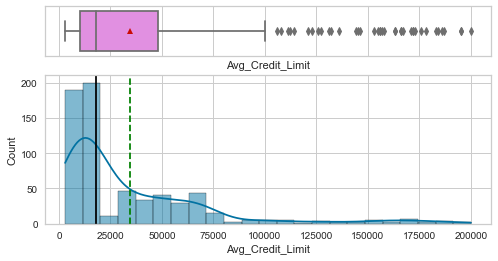

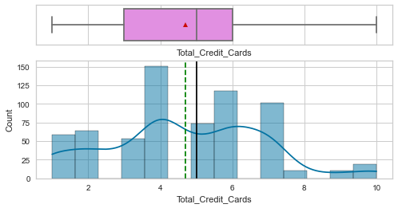

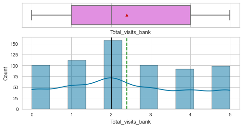

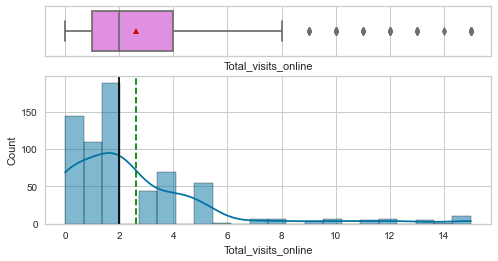

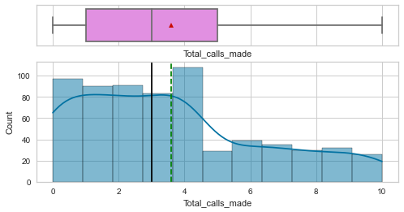

```python
for item in df:
    histogram_boxplot(df, item, kde=True, figsize=(8, 4))
```

- The Avg_Credit_Limit distribution is highly right-skewed as earlier mentioned with a lot of outliers to the far right. 75% of the clients have their Avg_Credit_Limit below 50,000
- The Total_Credit_Cards possessed by clients varies but 75% of them have at most 6.
- Most clients of the bank do not do more than 4 personal visits to the bank yearly.
- The Total_visits_online also has right-skewed distribution with outliers to the right as 75% of the clients only visit the bank online not more than 4 times a year.
- The Total_calls_made to the bank shows a right-skewed distribution too as most clients make at most 5 calls to the bank yearly

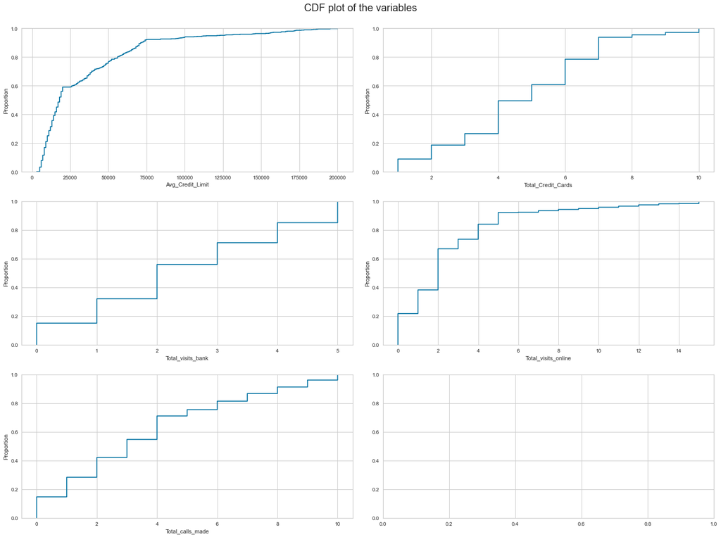

```python
# to plot the cummulative distribution function of the variables
num_col = df.columns
fig, axes = plt.subplots(3, 2, figsize=(20, 15))
fig.suptitle("CDF plot of the variables", fontsize=20)
counter = 0
for ii in range(3):
    sns.ecdfplot(ax=axes[ii][0], x=df[num_col[counter]])
    counter = counter + 1
    if counter != 5:
        sns.ecdfplot(ax=axes[ii][1], x=df[num_col[counter]])
        counter = counter + 1
    else:
        pass

fig.tight_layout(pad=2.0)
```

- About 90% of the bank's clients have average credit limit not more than 75,000
- Approximately 95% of the clients do not have more than 8 credit cards.
- Approximately 85% of the clients do not visit the bank personally more than 4 times yearly.
- Approximately 90% of the clients do not visit the bank online more than 5 times yearly.
- Approximately 90% of the clients do not make more than 8 calls to the bank yearly.

```python
# function to create labeled barplots


def labeled_barplot(data, feature, perc=False, n=None):
    """
    Barplot with percentage at the top

    data: dataframe
    feature: dataframe column
    perc: whether to display percentages instead of count (default is False)
    n: displays the top n category levels (default is None, i.e., display all levels)
    """

    total = len(data[feature])  # length of the column
    count = data[feature].nunique()
    if n is None:
        plt.figure(figsize=(count + 1, 5))
    else:
        plt.figure(figsize=(n + 1, 5))

    plt.xticks(rotation=90, fontsize=15)
    ax = sns.countplot(
        data=data,
        x=feature,
        palette="Paired",
        order=data[feature].value_counts().index[:n].sort_values(),
    )

    for p in ax.patches:
        if perc == True:
            label = "{:.1f}%".format(
                100 * p.get_height() / total
            )  # percentage of each class of the category
        else:
            label = p.get_height()  # count of each level of the category

        x = p.get_x() + p.get_width() / 2  # width of the plot
        y = p.get_height()  # height of the plot

        ax.annotate(
            label,
            (x, y),
            ha="center",
            va="center",
            size=12,
            xytext=(0, 5),
            textcoords="offset points",
        )  # annotate the percentage

    plt.show()  # show the plot
```

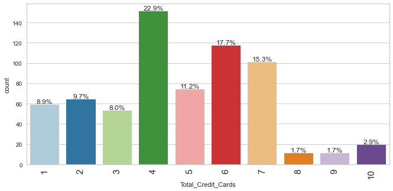

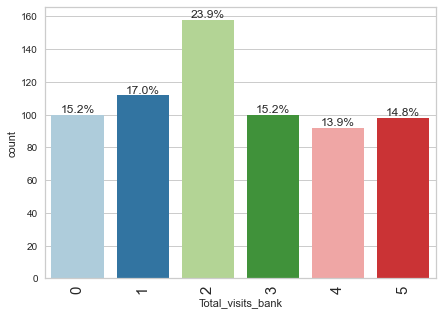

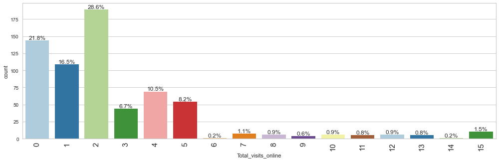

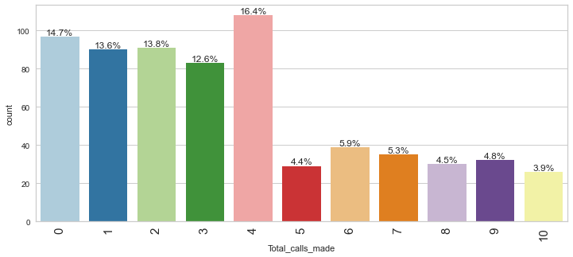

```python
# Creating labeled bar plots on all variables aside Avg_Credit_Limit
perc_col = df.drop("Avg_Credit_Limit", axis=1)
for item in perc_col:
    labeled_barplot(df, item, perc=True)
```

- Clients with 4 credit cards in total constitute the highest percentage(22.9%) while those with 8 or 9 cards are the least(1.7% each)
- Clients who visit the bank personally twice yearly constitute the highest percentage (23.9%) while those who visit 4 times are the least(13.9%)
- Clients who visit the bank online only twice constitute the highest percentage of 28.6% with 6 times and 14 times online visitors constituting the least population.
- Those clients that make 4 calls to the bank yearly constitute the highest percentage(16.4%) while those who make up to 10 calls are the least(3.9%)

### Bivariate Analysis

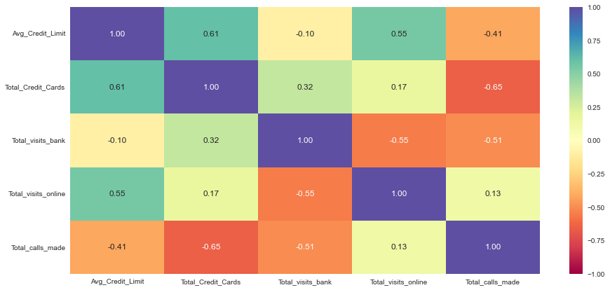

```python
# To plot the heat map of all correlation coefficients between pairs of the variables
plt.figure(figsize=(15, 7))
sns.heatmap(df[num_col].corr(), annot=True, vmin=-1, vmax=1, fmt=".2f", cmap="Spectral")
plt.show()
```

- The highest positive correlation between variables in the data set is between Avg_Credit_Limit and Total_Credit_Cards(0.61). This implies that a positve change in Avg_Credit_Limit will often witness a positive change in Total_Credit_Cards and vice versa.
- We see the highest negative correlation(-0.65) between Total_calls_made and Total_Credit_Cards. This suggests that when Total_Credit_Cards increases, the Total_calls_made tends to decrease and vice versa.
- We see a high negative correlation also (-0.55) between Total_visits_online and Total_visits_bank. This is expected because when customers enquiries are properly addressed via one channel of reaching the bank, they are not likely to explore the other channels on the same matter again.

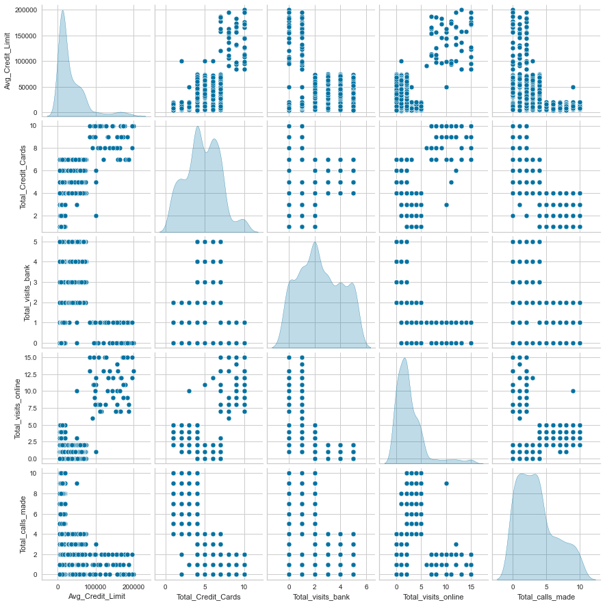

```python
# To plot the pairplot of all pairs of the variables in the dataset
sns.pairplot(data=df[num_col], diag_kind="kde")
plt.show()
```

- The pair plot displays various distributions and some even shows distinct clusters which may exist in the dataset and need to be further explored.

### Scaling the data

```python
# Scaling the data set before clustering
df_scaled = df.apply(zscore, ddof=0)
df_scaled.head(10)  # To display the first ten rows of the scaled data set
```

|  | Avg_Credit_Limit | Total_Credit_Cards | Total_visits_bank | Total_visits_online | Total_calls_made |
| --- | --- | --- | --- | --- | --- |
| 0 | 1.740187 | -1.249225 | -0.860451 | -0.547490 | -1.251537 |
| 1 | 0.410293 | -0.787585 | -1.473731 | 2.520519 | 1.891859 |
| 2 | 0.410293 | 1.058973 | -0.860451 | 0.134290 | 0.145528 |
| 3 | -0.121665 | 0.135694 | -0.860451 | -0.547490 | 0.145528 |
| 4 | 1.740187 | 0.597334 | -1.473731 | 3.202298 | -0.203739 |
| 5 | -0.387644 | -0.787585 | -1.473731 | -0.547490 | 1.542593 |
| 6 | 1.740187 | 0.135694 | -1.473731 | 2.861408 | -0.553005 |
| 7 | -0.520633 | -0.787585 | -1.473731 | -0.547490 | -0.902271 |
| 8 | -0.786612 | -1.249225 | -1.473731 | -0.206600 | -0.553005 |
| 9 | -0.839808 | -0.325946 | -1.473731 | -0.547490 | 1.193326 |

### Kmeans Clustering

```
Number of Clusters: 1 	Average Distortion: 2.0069222262503614
Number of Clusters: 2 	Average Distortion: 1.4571553548514269
Number of Clusters: 3 	Average Distortion: 1.1466276549150365
Number of Clusters: 4 	Average Distortion: 1.0463825294774465
Number of Clusters: 5 	Average Distortion: 0.9904384353071455
Number of Clusters: 6 	Average Distortion: 0.9429951888252038
Number of Clusters: 7 	Average Distortion: 0.9095661498049182
Number of Clusters: 8 	Average Distortion: 0.8901300416929311
Number of Clusters: 9 	Average Distortion: 0.8667853484551529
```

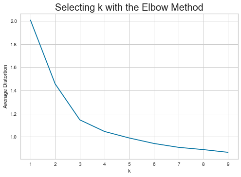

```python
# To check for the appropriate number of K using the Elbow method
clusters = range(1, 10)
meanDistortions = []

for k in clusters:
    model = KMeans(n_clusters=k)
    model.fit(df_scaled)
    prediction = model.predict(df_scaled)
    distortion = (
        sum(np.min(cdist(df_scaled, model.cluster_centers_, "euclidean"), axis=1))
        / df_scaled.shape[0]
    )

    meanDistortions.append(distortion)

    print("Number of Clusters:", k, "\tAverage Distortion:", distortion)

plt.plot(clusters, meanDistortions, "bx-")
plt.xlabel("k")
plt.ylabel("Average Distortion")
plt.title("Selecting k with the Elbow Method", fontsize=20)
```

- The appropriate value of k from the elbow curve seems to be 2 or 3.

**Let's check the silhouette scores.**

```
For n_clusters = 2, silhouette score is 0.41842496663215445
For n_clusters = 3, silhouette score is 0.5157182558881063
For n_clusters = 4, silhouette score is 0.3556670619372605
For n_clusters = 5, silhouette score is 0.271579890845465
For n_clusters = 6, silhouette score is 0.2553892519918698
For n_clusters = 7, silhouette score is 0.2497536706416199
For n_clusters = 8, silhouette score is 0.22741644126426583
For n_clusters = 9, silhouette score is 0.22158440233992951
```

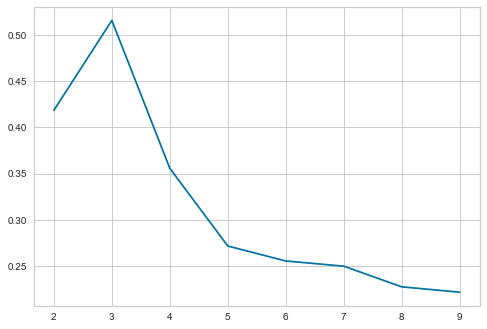

```python
# To check for the appropriate number of K using the silhouette scores
sil_score = []
cluster_list = list(range(2, 10))
for n_clusters in cluster_list:
    clusterer = KMeans(n_clusters=n_clusters)
    preds = clusterer.fit_predict((df_scaled))

    score = silhouette_score(df_scaled, preds)
    sil_score.append(score)
    print("For n_clusters = {}, silhouette score is {}".format(n_clusters, score))

plt.plot(cluster_list, sil_score)
```

- From the silhouette scores, it seems that 3 is a good value of K since it has the highest score of 0.52.

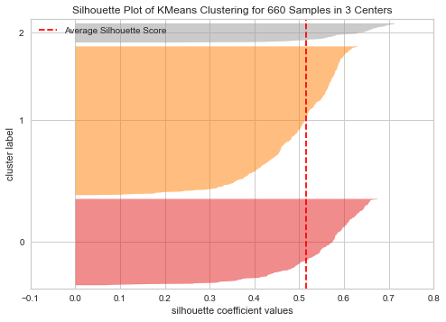

```python
# finding optimal no. of clusters with silhouette coefficients
visualizer = SilhouetteVisualizer(KMeans(3, random_state=1))
visualizer.fit(df_scaled)
visualizer.show()
```

- It appears that clustering the data set into 3 is appropriate as each of the 3 clusters silhouette coefficient is above the average silhouette score of 0.52. The fatness of the cluster label 1 suggests it contains the highest number of clients while cluster label 2 contains the least number of clients. This shall be explored further below. We shall further confirm this during customer profiling

```python
# let's take 3 as number of clusters and fit the KMeans clustering model on the scaled data
kmeans = KMeans(n_clusters=3, random_state=1)
kmeans.fit(df_scaled)
```

```
KMeans(n_clusters=3, random_state=1)
```

```python
# Adding kmeans cluster labels to the original and scaled dataframes
df["K_means_segments"] = kmeans.labels_
df_scaled["K_means_segments"] = kmeans.labels_
```

### KMeans Cluster Profiling

```python
# To profile the customers based on the kmeans cluster labels
cluster_profile = df.groupby("K_means_segments").mean()
```

```python
# To group the customers using their Avg_Credit_Limit
cluster_profile["count_in_each_segments"] = (
    df.groupby("K_means_segments")["Avg_Credit_Limit"].count().values
)
```

```python
# let's display cluster profiles
cluster_profile.style.highlight_max(color="lightgreen", axis=0)
```

| K_means_segments | Avg_Credit_Limit | Total_Credit_Cards | Total_visits_bank | Total_visits_online | Total_calls_made | count_in_each_segments |
| --- | --- | --- | --- | --- | --- | --- |
| 0 | 12174.107143 | 2.410714 | 0.933036 | 3.553571 | 6.870536 | 224 |
| 1 | 33782.383420 | 5.515544 | 3.489637 | 0.981865 | 2.000000 | 386 |
| 2 | 141040.000000 | 8.740000 | 0.600000 | 10.900000 | 1.080000 | 50 |

**Cluster 0

- The clients here generally have the lowest credit limit(average of 12,174), lowest number of credit cards(2.4) and mostly reach the bank via calls(approximately 7 times yearly). 224 clients are in this group.

**Cluster 1

- The clients here occupies the middle class in terms of their credit limit(the mean credit limit for clients here is 33,782) and total credit cards possessed(with mean of 5.5) but reach the bank mostly by visiting personally. They constitute the bulk of the bank's clients as 386 are in this group.

**Cluster 2

- The clients in the group are the ones who enjoy the highest credit limit(with mean of 141,040) and have the highest number of credit cards (with mean of 8.7) but mostly reach the bank through the online channels. They however are the least in number totalling 50.

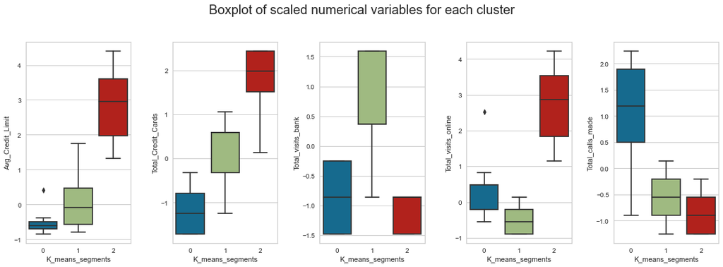

```python
# To plot the boxplot of the scaled variables for each cluster
fig, axes = plt.subplots(1, 5, figsize=(16, 6))
fig.suptitle("Boxplot of scaled numerical variables for each cluster", fontsize=20)
counter = 0
for ii in range(5):
    sns.boxplot(
        ax=axes[ii],
        y=df_scaled[num_col[counter]],
        x=df_scaled["K_means_segments"],
    )
    counter = counter + 1

fig.tight_layout(pad=2.0)
```

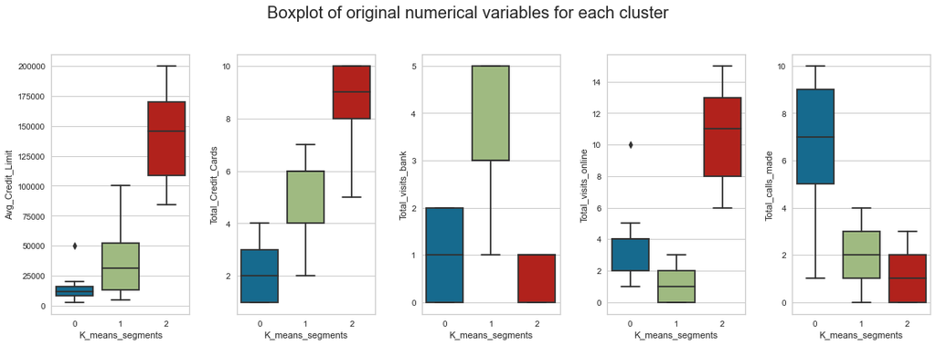

```python
# To plot the boxplot of the original variables for each cluster
fig, axes = plt.subplots(1, 5, figsize=(16, 6))
fig.suptitle("Boxplot of original numerical variables for each cluster", fontsize=20)
counter = 0
for ii in range(5):
    sns.boxplot(ax=axes[ii], y=df[num_col[counter]], x=df["K_means_segments"])
    counter = counter + 1

fig.tight_layout(pad=2.0)
```

- The boxplots above further confirms graphically the characteristics of each cluster based on the variables in the data set as explained earlier under the clusters profile.

### Hierarchical Clustering

```python
# To get the cophenitic correlation of each pair of distance and linkage method

# list of distance metrics to apply on the data set
distance_metrics = ["euclidean", "chebyshev", "mahalanobis", "cityblock"]

# list of linkage methods to apply
linkage_method = ["single", "complete", "average", "centroid", "ward", "weighted"]
linkage_method_ = ["single", "complete", "average", "weighted"]

high_cophenet_corr = 0
high_dm_lm = [0, 0]

for dm in distance_metrics:
    if dm == "euclidean":
        for lm in linkage_method:
            Z = linkage(df_scaled, metric=dm, method=lm)
            c, coph_dists = cophenet(Z, pdist(df_scaled))
            print(
                "Cophenetic correlation for {} distance and {} linkage is {}.".format(
                    dm.capitalize(), lm, c
                )
            )
            if high_cophenet_corr < c:
                high_cophenet_corr = c
                high_dm_lm[0] = dm
                high_dm_lm[1] = lm
    else:
        for lm in linkage_method_:
            Z = linkage(df_scaled, metric=dm, method=lm)
            c, coph_dists = cophenet(Z, pdist(df_scaled))
            print(
                "Cophenetic correlation for {} distance and {} linkage is {}.".format(
                    dm.capitalize(), lm, c
                )
            )
            if high_cophenet_corr < c:
                high_cophenet_corr = c
                high_dm_lm[0] = dm
                high_dm_lm[1] = lm
```

```
Cophenetic correlation for Euclidean distance and single linkage is 0.8981791108157512.
Cophenetic correlation for Euclidean distance and complete linkage is 0.884420725860894.
Cophenetic correlation for Euclidean distance and average linkage is 0.9102691112621796.
Cophenetic correlation for Euclidean distance and centroid linkage is 0.906845257340526.
Cophenetic correlation for Euclidean distance and ward linkage is 0.7566252666432097.
Cophenetic correlation for Euclidean distance and weighted linkage is 0.9069999252384202.
Cophenetic correlation for Chebyshev distance and single linkage is 0.8142004375043415.
Cophenetic correlation for Chebyshev distance and complete linkage is 0.8565360723350399.
Cophenetic correlation for Chebyshev distance and average linkage is 0.9092248615295281.
Cophenetic correlation for Chebyshev distance and weighted linkage is 0.9046661477870559.
Cophenetic correlation for Mahalanobis distance and single linkage is 0.8650806042953477.
Cophenetic correlation for Mahalanobis distance and complete linkage is 0.6100510675083298.
Cophenetic correlation for Mahalanobis distance and average linkage is 0.8419295288198599.
Cophenetic correlation for Mahalanobis distance and weighted linkage is 0.8593103662232748.
Cophenetic correlation for Cityblock distance and single linkage is 0.8519946783967026.
Cophenetic correlation for Cityblock distance and complete linkage is 0.8928953430241594.
Cophenetic correlation for Cityblock distance and average linkage is 0.908076618085445.
Cophenetic correlation for Cityblock distance and weighted linkage is 0.8862785891794108.
```

```python
# printing the combination of distance metric and linkage method with the highest cophenetic correlation
print(
    "Highest cophenetic correlation is {}, which is obtained with {} distance and {} linkage.".format(
        high_cophenet_corr, high_dm_lm[0].capitalize(), high_dm_lm[1]
    )
)
```

```
Highest cophenetic correlation is 0.9102691112621796, which is obtained with Euclidean distance and average linkage.
```

#### Let's see the dendrograms for the different linkage methods.

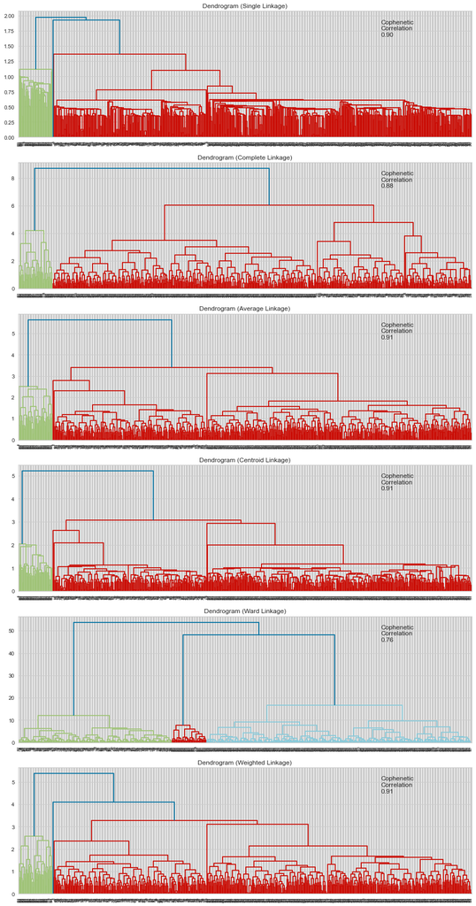

```python
# lists to save results of cophenetic correlation calculation
compare_cols = ["Linkage", "Cophenetic Coefficient"]

# to create a subplot image
fig, axs = plt.subplots(len(linkage_method), 1, figsize=(15, 30))

# We will enumerate through the list of linkage_method above
# For each linkage method, we will plot the dendrogram and calculate the cophenetic correlation
for i, method in enumerate(linkage_method):
    Z = linkage(df_scaled, metric="euclidean", method=method)

    dendrogram(Z, ax=axs[i])
    axs[i].set_title(f"Dendrogram ({method.capitalize()} Linkage)")

    coph_corr, coph_dist = cophenet(Z, pdist(df_scaled))
    axs[i].annotate(
        f"Cophenetic\nCorrelation\n{coph_corr:0.2f}",
        (0.80, 0.80),
        xycoords="axes fraction",
    )
```

**Observations**

```python
#fitting the hierarchical model on the scaled data with 3 clusters
HCmodel = AgglomerativeClustering(n_clusters=3, affinity="euclidean", linkage="average")
HCmodel.fit(df_scaled)
```

```
AgglomerativeClustering(linkage='average', n_clusters=3)
```

```python
# Adding Hierarchical cluster labels to the original and scaled dataframes
df["HC_Clusters"] = HCmodel.labels_
df_scaled["HC_Clusters"] = HCmodel.labels_
```

### Hierarchical Cluster Profiling

```python
# To profile the customers based on the Hierarchical cluster labels
cluster_profile_ = df.groupby("HC_Clusters").mean()
```

```python
# To group the customers using their Avg_Credit_Limit
cluster_profile_["count_in_each_segments"] = (
    df.groupby("HC_Clusters")["Avg_Credit_Limit"].count().values
)
```

```python
# lets display cluster profile
cluster_profile_.style.highlight_max(color="lightgreen", axis=0)
```

| HC_Clusters | Avg_Credit_Limit | Total_Credit_Cards | Total_visits_bank | Total_visits_online | Total_calls_made | K_means_segments | count_in_each_segments |
| --- | --- | --- | --- | --- | --- | --- | --- |
| 0 | 33782.383420 | 5.515544 | 3.489637 | 0.981865 | 2.000000 | 1.000000 | 386 |
| 1 | 141040.000000 | 8.740000 | 0.600000 | 10.900000 | 1.080000 | 2.000000 | 50 |
| 2 | 12174.107143 | 2.410714 | 0.933036 | 3.553571 | 6.870536 | 0.000000 | 224 |

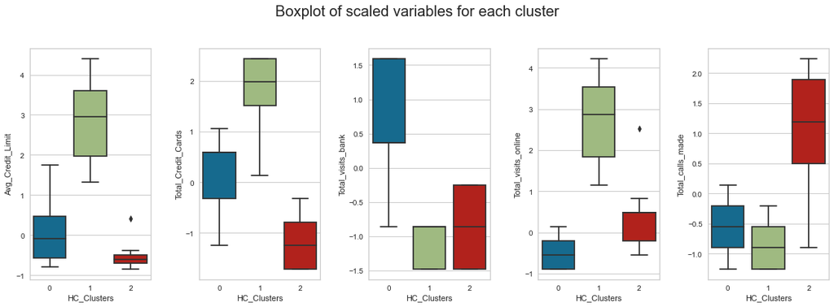

```python
# To plot the boxplot of the scaled variables for each cluster
fig, axes = plt.subplots(1, 5, figsize=(16, 6))
fig.suptitle("Boxplot of scaled variables for each cluster", fontsize=20)
counter = 0
for ii in range(5):
    sns.boxplot(
        ax=axes[ii],
        y=df_scaled[num_col[counter]],
        x=df_scaled["HC_Clusters"],
    )
    counter = counter + 1

fig.tight_layout(pad=2.0)
```

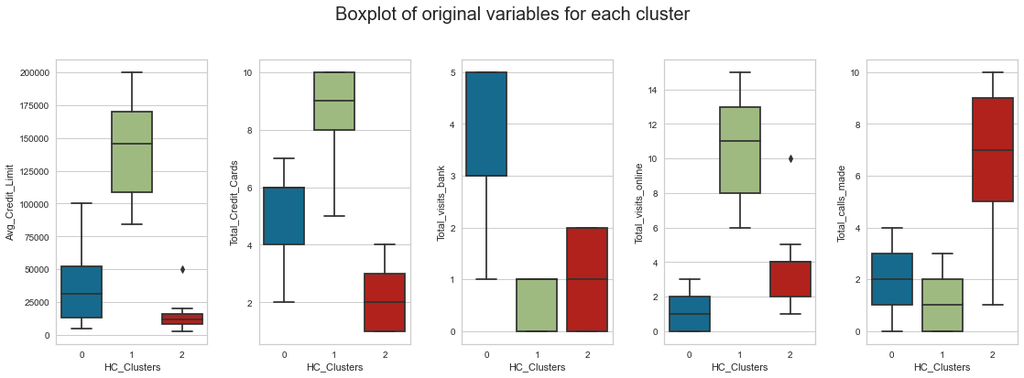

```python
# To plot the boxplot of the original variables for each cluster
fig, axes = plt.subplots(1, 5, figsize=(16, 6))
fig.suptitle("Boxplot of original variables for each cluster", fontsize=20)
counter = 0
for ii in range(5):
    sns.boxplot(
        ax=axes[ii],
        y=df[num_col[counter]],
        x=df["HC_Clusters"],
    )
    counter = counter + 1

fig.tight_layout(pad=2.0)
```

**Cluster 0

- The clients here occupies the middle class in terms of Average credit limit(between 12,500-55,000) and total credit cards possessed(between 4-6) but reach the bank mostly by visiting personally(3-5 times yearly). They constitute the bulk of the bank's clients as 386 are in this cluster.

**Cluster 1

- The clients in the group are the ones who enjoy the highest average credit limit(between 80,000-200,000) and have the highest number of credit cards(between 8-10) but mostly reach the bank through the online channels(between (6-15 times yearly). They however are the least in number totalling 50.

**Cluster 2

- The clients here generally have the lowest average credit limit(with most of them having credit limit below 25,000), lowest number of credit cards(mostly below 4) and mostly reach the bank through calls(5-10 times yearly). 224 clients are in this cluster.

### K-means vs Hierarchical Clustering

- The two techniques suggest the same number of clusters (i.e. 3) that exist in the dataset.
- K-means clustering actually takes lesser time to compute than Hierarchical Clustering,
- Comparing the clusters obtained through K-Means and Hierarchical Clustering techniques, except the Cluster name that differs, they are very similar in profile.

  ```
  * Cluster 0 under K-Means Clustering is the same as Cluster 2 under Hierarchical Clustering. They also contain the same number of observations(224)
  * Cluster 1 under K-Means Clustering is the same as Cluster 0 under Hierarchical Clustering containing the same number of observations(386)
  * Cluster 2 under K-Means Clustering is the same as Cluster 1 under Hierarchical Clustering containing the same number of observations(50)
  ```

## Summary of Insights

The credit card customers of Alllife Bank can be classified into three distinct segments and there segments profiles in no particular order is displayed below:

** First Segment

- The clients with low credit limit(with most of them having credit limit below 25,000), low number of credit cards(mostly below 4) and mostly reach the bank through calls. 224 clients are in this segment.

** Second Segment

- The clients with average credit limit(between 12,500-55,000), average number credit cards, and reach the bank mostly by visiting personally. They constitute the bulk of the bank's credit card clients as 386 are in this segment.

** Third Segment

- The clients with high credit limit(between 80,000-200,000), high number of credit cards, and mostly reach the bank through the online channels. They however are the least in number totalling 50.

## Recommendations

** Whenever the marketing team runs personalized campaigns to target new customers as well as upsell to existing customers, such campaigns have to be pitched through the three channels of reaching the bank(i.e personal visit, online channel, and call centers) so as to reach all the three segments of the customers identified. However, there should be special focus on customers in second segment identified under 'Insights' above as they constitute the bulk of the bank's credit card customers. Therefore positioning such campaigns more during customer's personal visitations to the bank will likely yield better result.

** Secondly, for the customers' perception of the bank's support services to change positively, services need to be improved upon at all service points especially when interfacing with customers on personal visits to the bank. The bank may need to increase their manpower at the in-branch customer service desks and/or train/re-train the staff on how to deliver excellent customer services.